# The Sampling Bowl Modern Dive Chapter 7

October 06, 2021 @ 03:04 PM

## Before We Begin…

These slides are not meant to be standalone information. You should take notes to flesh out the contents. I recommend that you create an R Markdown document where you can combine information and code from the slides and your own additional notes and explorations to make connections.

**Related Materials**

- Ch 7 of [*Modern Dive*](https://moderndive.com/7-sampling.html) (basis for this activity)
- DataCamp [Foundations of Probability in R](https://learn.datacamp.com/courses/foundations-of-probability-in-r)
- DataCamp [Sampling in R](https://learn.datacamp.com/courses/sampling-in-r)

## Packages

```r
library(tidyverse)
```

We need `tidyverse` for all our basic data manipulation. Recall that this includes `dplyr` and `ggplot`, among other packages in the `tidyverse` suite of tools.

```r
library(moderndive)
```

We need `moderndive` for some of the data and functions used in the sampling bowl activity.

```r
library(gridExtra)
```

We need `gridExtra` to arrange and display multiple plots.

## Our Population: The “Bowl”

What proportion of the balls are red? We could count all of them (take a *census*), but that would be a long process (\(N\) = 2400).

[figure not shown]

MD Figure 7.1: A bowl filled with red and white balls.

## Our Sample: The “Shovel”

Instead of counting the entire population (*census*), we can select a random sample to use as an estimate (\(n\) = 50 here).

[figure not shown]

MD Figure 7.3: Removing 50 balls from the bowl.

## What is the Distribution?

If we were sampling *with replacement*—drawing one ball, noting its color, and putting it back before drawning another—we could model our sample with a binomial distribution. The parameter \(p\) would be the true proportion of red balls.

We are sampling *without replacement* here, which is often more realistic with respect to real-world situations. If we think of each slot on the “shovel” being filled in order, the color of the ball that fills each slot changes the color probabilities of the subsequent balls (this would be a *hypergeometric* model).

Note: In real-world problems where the sample size *n* is very small compared to overall population size, we use the binomial model anyway when sampling without replacement. Why?

## Random Sampling

Assuming there are more than 50 red balls and 50 white balls in the bowl, when we select a random sample of 50 balls we *could* get anywhere from 0 to 50 red balls.

That means all proportions from 0 = 0% to 1 = 100% are *possible*. But are they all equally *probable*? Why or why not?

## Virtual Sampling

We cannot physically replicate this experiment, but we can do so virtually. The `moderndive` package contains a virtual object `bowl` that represents the physical object.

Scoop one `virtual_shovel` of balls using the following code.

```r
virtual_shovel <- bowl %>% rep_sample_n(size = 50, reps = 1)
```

The `rep_sample_n()` function is from the package `infer` and is used by the package `moderndive`.

```
rep_sample_n(tbl, size, replace = FALSE, reps = 1, prob = NULL)
```

Defaults are sampling *without* replacement, equal probability of being selected, and one repetition of the chosen size.

## Proportion of Red Balls

The proportion of red balls in your sample is an *estimate* of the proportion of red balls in the `bowl`.

```r
virtual_shovel %>%
  mutate(is_red = color == "red") %>%
  summarize(num_red  = sum(is_red),
            prop_red = mean(is_red))
```

Note that the code is slightly different than the code found in Modern Dive, Chapter 7. This code is algebraically equivalent, but automatically works for sample sizes other than 50.

What if we wanted to calculate the proportion of white balls in the sample instead? How would you adapt the code?

GIVE IT A TRY!

## Results of My Sample

Here are the results of my sample. What should the numbers of red and white balls add up to? What about the proportions?

```r
virtual_shovel %>%
  mutate(is_red   = color == "red",
         is_white = color == "white") %>%
  summarize(num_red    = sum(is_red),
            prop_red   = mean(is_red),
            num_white  = sum(is_white),
            prop_white = mean(is_white))
```

```
# A tibble: 1 × 5
  replicate num_red prop_red num_white prop_white
      <int>   <int>    <dbl>     <int>      <dbl>
1         1      19     0.38        31       0.62
```

## Taking Multiple Samples

In the physical scenario described in Modern Dive, there were 33 students in the class, each of whom drew one sample from the physical `bowl`. Their results are shown below.

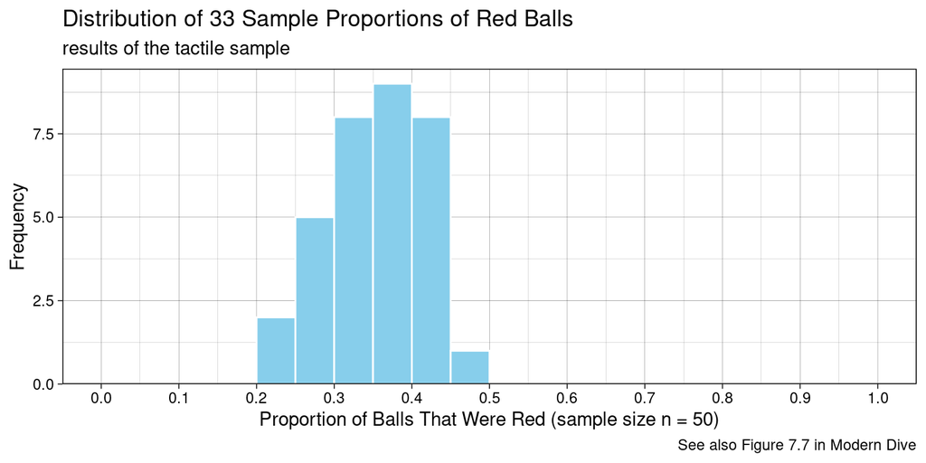

## True Proportion of Red

What seems like the most probable value for \(p\) = proportion of red balls in the `bowl`, based on the plot of 33 samples? Why?

(We *could* calculate it directly from the `bowl` object, but in most real-life scenarios we cannot access the population—that is why we sample! Exploring cases where the solution is known is how we develop reliable methods for unknown cases.)

## Virtually Replicate the 33 Samples

Thanks to the power of computers, you can replicate the class sampling process. Set the `reps` to 33 so you get one sample of size 50 for each virtual student.

```r
virtual_samples <- bowl %>%
  rep_sample_n(size = 50, reps = 33)
```

Calculate the count and proportion of red balls in each sample (i.e., each `replicate` here).

```r
virtual_prop_red <- virtual_samples %>%
  group_by(replicate) %>%
  mutate(is_red = color == "red") %>%
  summarize(num_red  = sum(is_red),
            prop_red = mean(is_red))
```

## Our Data is the Sample Proportions

We are interested in \(\hat{p}\) = proportion of red balls in each of the 33 samples, not individual ball colors. That *statistic* is our data.

```
# A tibble: 33 × 3
   replicate num_red prop_red
       <int>   <int>    <dbl>
 1         1      25     0.5
 2         2      21     0.42
 3         3      13     0.26
 4         4      24     0.48
 5         5      20     0.4
 6         6      22     0.44
 7         7      27     0.54
 8         8      18     0.36
 9         9      11     0.22
10        10      13     0.26
# … with 23 more rows
```

## Tactile vs. Virtual Results

Tactile results will always be the same. Virtual results will differ unless we `set.seed()` to control our pseudo-random stream.

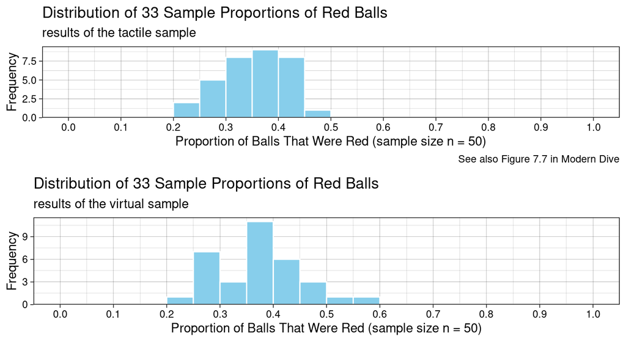

## Sampling Distribution of \(\hat{p}\)

We need to understand the *sampling distribution* of any statistic that is used to estimate a population parameter. Here, we use \(\hat{p}\) (sample proportion) estimates \(p\) (population proportion).

Just like we did in EDA, we characterize distributions by:

- shape
- center
- spread (variability)

Note: Some sources use \(p\) for the sample proportion and \(\pi\) for the population proportion, following the convention of using Greek letters for parameters. Be sure you know which symbols are being used!

## Empirical Estimate

Estimate *empirically* (i.e., using data from your virtual samples vs. using theory) the shape, center, and spread (i.e., variability) of the sampling distribution of \(\hat{p}\).

How could you modify your virtual experiment / simulation to help you get a better sense of the distribution?

## Center and Spread

Usually we characterize center and spread using mean and SD or variance. We also refer to the mean as the *expected value* in the case of theoretical models (as a reminder).

When dealing with empirical data, compute the mean and SD of the various values of the statistic you got from sampling.

```
# A tibble: 1 × 2
  mean_props sd_props
       <dbl>    <dbl>
1      0.381   0.0850
```

Thus, our estimate of \(\mu_{\hat{p}}\) is 0.3812121 and our estimate of \(\sigma_{\hat{p}}\) is 0.0849911. The standard deviation of a sampling distribution is called the *standard error* (SE) and depends on the sample size.

## Is the Distribution Bell-Shaped?

We already saw a histogram of the data, but we can also make other plots, such as a normal QQ plot to assess normality.

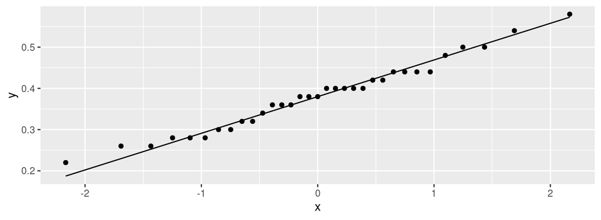

```r
ggplot(virtual_prop_red, aes(sample = prop_red)) +
  geom_qq() +
  geom_qq_line()
```

## Taking More Samples!

Our 33 random samples are a very small experiment if we are trying to understand the true variability that can be observed from sample to sample. Let’s take more samples!

Adapt the code to take 1000 samples of size 50. Summarize the count and proportion of red balls in each sample and save it as `virtual_prop_red_1000`. Compute the mean and SE of \(\hat{p}\) and determine the shape. Is it approximately normal?

## 1000 Virtual Samples

```r
virtual_prop_red_1000 <- bowl %>%
  rep_sample_n(size = 50, reps = 1000) %>%
  group_by(replicate) %>%
  mutate(is_red = color == "red") %>%
  summarize(num_red  = sum(is_red),
            prop_red = mean(is_red))

virtual_prop_red_1000 %>%
  summarize(mean_props = mean(prop_red),
            sd_props   = sd(prop_red))
```

```
# A tibble: 1 × 2
  mean_props sd_props
       <dbl>    <dbl>
1      0.374   0.0678
```

## Distribution Shape

What shape does your distribution of virtual samples appear to have? Can you say it is (approximately) a normal distribution?

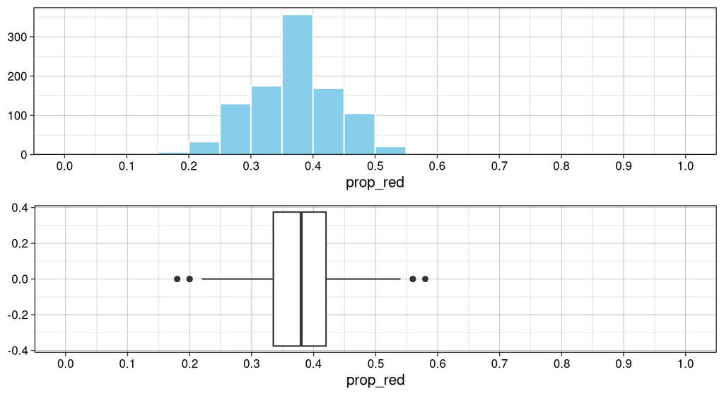

```r
library(moments)
virtual_prop_red_1000 %>%
  summarize(skew   = skewness(prop_red),
            exkurt = kurtosis(prop_red) - 3)
```

```
# A tibble: 1 × 2
      skew  exkurt
     <dbl>   <dbl>
1 -0.00916 -0.0570
```

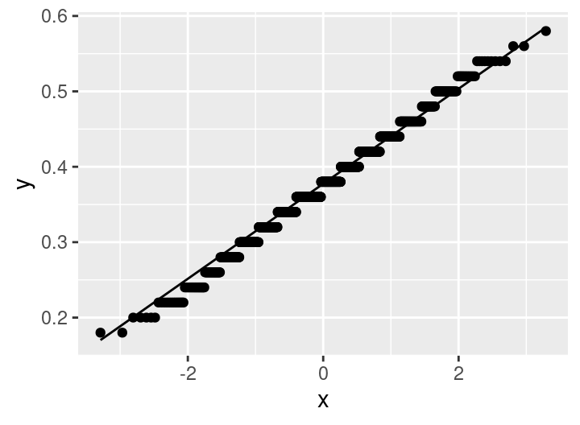

## Taking *Larger* Samples

Systematically conduct more experiments using different sample sizes (up to \(n\) = 2400, the number of balls in the bowl).

Using your data, answer the following questions.

- How does changing sample size affect shape?
- How does changing sample size affect center?
- How does changing sample size affect spread/variability?
- Can we use a normal model? If so, under what conditions?
- Can you make any other observations about the distribution?

Use 1000 reps, or else `rep_sample_n()` can get a little hung up.

## So what is the population proportion?

We can calculate the population proportions the same way we did with our sample data, but using the entire `bowl` dataset.

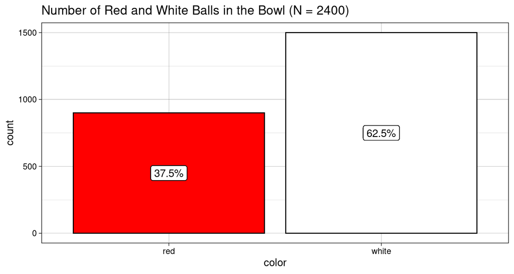